# Why Functional Programming: No More Copying and Pasting

D-Lab

# 1 Setup

```r
# Install packages
if (!require("pacman")) install.packages("pacman")
```

```r
pacman::p_load(tidyverse, # tidyverse pkgs including purrr
               tictoc, # performance test
               broom, # tidy modeling
               patchwork) # arranging ggplots
```

# 2 Objectives

- How to use `purrr` to automate workflow in a cleaner, faster, and more extendable way

# 3 Copy-and-paste programming

> Copy-and-paste programming, sometimes referred to as just pasting, is the production of highly repetitive computer programming code, as produced by copy and paste operations. It is primarily a pejorative term; those who use the term are often implying a lack of programming competence. It may also be the result of technology limitations (e.g., an insufficiently expressive development environment) as subroutines or libraries would normally be used instead. However, there are occasions when copy-and-paste programming is considered acceptable or necessary, such as for boilerplate, loop unrolling (when not supported automatically by the compiler), or certain programming idioms, and it is supported by some source code editors in the form of snippets. - Wikipedia
- The following exercise was inspired by [Wickham’s example](http://adv-r.had.co.nz/Functional-programming.html).
- Let’s imagine `df` is a survey data.
  - a, b, c, d = Survey questions
  - -99: non-responses
  - Your goal: replace -99 with NA

```r
# Data
df <- tibble("a" = -99,
             "b" = -99,
             "c" = -99,
             "d" = -99)
```

```r
# Copy and paste
df$a[df$a == -99] <- NA
df$b[df$b == -99] <- NA
df$c[df$c == -99] <- NA
df$d[df$d == -99] <- NA
```

- **Challenge 1**. Explain why this solution is not very efficient. (e.g., If `df$a[df$a == -99] <- NA` has an error, how are you going to fix it?) A solution is not scalable if it’s not automatable and, thus, scalable.

# 4 Using a function

- Let’s recall what’s function in R: input + computation + output
- If you write a function, you gain efficiency because you don’t need to copy and paste the computation part.

` function(input){

computation

return(output)

} `

```r
# Function
fix_missing <- function(x) {
  x[x == -99] <- NA
  # This is better
  return(x)
}

# Apply function to each column (vector)
df$a <- fix_missing(df$a)
df$b <- fix_missing(df$b)
df$c <- fix_missing(df$c)
df$d <- fix_missing(df$d)
```

- **Challenge 2** Why using function is more efficient than 100% copying and pasting? Can you think about a way we can automate the process?
- Many options for automation in R: `for loop`, `apply` family, etc.
- Here’s a tidy solution comes from `purrr` package.
- The power and joy of one-liner.

```r
purrr::map_df(df, fix_missing)
```

| a | b | c | d |
| --- | --- | --- | --- |
| NA | NA | NA | NA |

`map()` is a higher-order function that applies a given function to each element of a list/vector.

```
- Input: Takes a vector/list.

- Computation: Calls the function once for each element of the vector

- Output: Returns in a list or whatever data format you prefer (e.g., `_df helper: dataframe`)
```

**Challenge 3** If you run the code below, what’s going to be the data type of the output?

```r
map_chr(df, fix_missing)
```

```
##  a  b  c  d
## NA NA NA NA
```

- Why `map()` is a good alternative to `for loop`. (For more information, watch Hadley Wickam’s talk titled [“The Joy of Functional Programming (for Data Science)”](https://www.youtube.com/watch?v=bzUmK0Y07ck&ab_channel=AssociationforComputingMachinery%28ACM%29).)

```r
# Built-in data
data("airquality")
```

```r
# 0.029 sec elapsed
tic()

out1 <- vector("double", ncol(airquality)) # Placeholder

for (i in seq_along(airquality)) { # Sequence variable

  out1[[i]] <- mean(airquality[[i]], na.rm = TRUE) # Assign a computation result to each element

}

toc()
```

```
## 0.011 sec elapsed
```

```r
# 0.011 sec elapsed

tic()

out1 <- airquality %>% map_dbl(mean, na.rm = TRUE)

toc()
```

```
## 0.001 sec elapsed
```

- In short, `map()` is more readable, faster, and easily extensive with other data science tasks (e.g., wrangling, modeling, and visualization) using `%>%`.
- Final point: Why not base R `apply` family?

Short answer: `purrr::map()` is simpler to write. For instance,

`map_dbl(x, mean, na.rm = TRUE)` = `vapply(x, mean, na.rm = TRUE, FUN.VALUE = double(1))`

**Additional tips**

Performance testing (profiling) is an important part of programming. `tictic()` measures the time that needs to take to run a target function for once. If you want a more robust measure of timing as well as information on memory (**speed** and **space** both matter for performance testing), consider using the [`bench` package](https://github.com/r-lib/bench) that is designed for high precising timing of R expressions.

```r
map_mark <- bench::mark(

  out1 <- airquality %>% map_dbl(mean, na.rm = TRUE)

  )

map_mark
```

```
## # A tibble: 1 x 6
##   expression                                              min   median `itr/sec`
##   <bch:expr>                                         <bch:tm> <bch:tm>     <dbl>
## 1 out1 <- airquality %>% map_dbl(mean, na.rm = TRUE)   62.5µs   78.1µs    10833.
## # … with 2 more variables: mem_alloc <bch:byt>, gc/sec <dbl>
```

# 5 Applications

1. Many models
- One popular application of `map()` is to run regression models (or whatever model you want to run) on list-columns. No more copying and pasting for running many regression models on subgroups!

```r
# Have you ever tried this?
lm_A <- lm(y ~ x, subset(data, subgroup == "group_A"))
lm_B <- lm(y ~ x, subset(data, subgroup == "group_B"))
lm_C <- lm(y ~ x, subset(data, subgroup == "group_C"))
lm_D <- lm(y ~ x, subset(data, subgroup == "group_D"))
lm_E <- lm(y ~ x, subset(data, subgroup == "group_E"))
```

- For more information on this technique, read the Many Models subchapter of the [R for Data Science](https://r4ds.had.co.nz/many-models.html#creating-list-columns).

```r
# Function
lm_model <- function(df) {
  lm(Temp ~ Ozone, data = df)
}
```

```r
# Map
models <- airquality %>%
  # Determines group variable
  group_by(Month) %>%
  nest() %>% # Create list-columns
  mutate(ols = map(data, lm_model)) # Map
```

```r
# Add tidying
tidy_lm_model <- purrr::compose( # compose multiple functions
  broom::tidy, # convert lm objects into tidy tibbles
  lm_model
)

tidied_models <- airquality %>%
  group_by(Month) %>%
  nest() %>% # Create list-columns
  mutate(ols = map(data, tidy_lm_model))

tidied_models$ols[1]
```

```
## [[1]]
## # A tibble: 2 x 5
##   term        estimate std.error statistic  p.value
##   <chr>          <dbl>     <dbl>     <dbl>    <dbl>
## 1 (Intercept)   62.9      1.61       39.2  2.88e-23
## 2 Ozone          0.163    0.0500      3.26 3.31e- 3
```

2. Simulations

A good friend of `map()` function is `rerun()` function. This comibination is really useful for simulations. Consider the following example.

- Base R approach

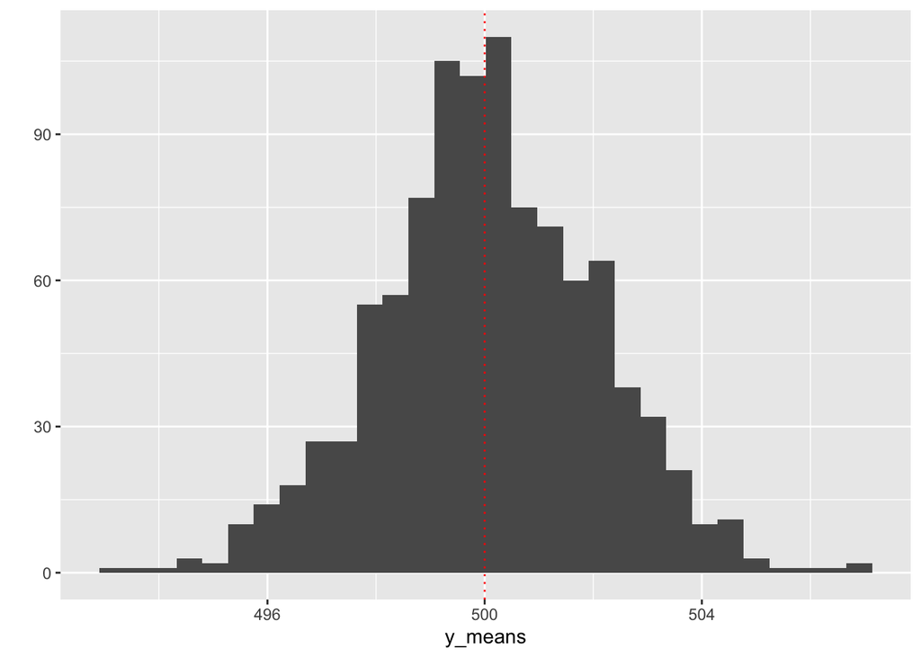

```r
set.seed(1234)

small_n <- 100 ; k <- 1000 ; mu <- 500 ; sigma <- 20

y_list <- rep(list(NA), k)

for (i in seq(k)) {

    y_list[[i]] <- rnorm(small_n, mu, sigma)

}

y_means <- unlist(lapply(y_list, mean))

qplot(y_means) +
   geom_vline(xintercept = 500, linetype = "dotted", color = "red")
```

- rerun() + map()

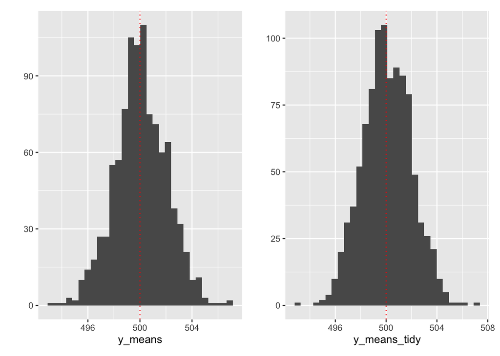

```r
small_n <- 100 ; k <- 1000

y_tidy <- rerun(k, rnorm(small_n, mu, sigma))

y_means_tidy <- map_dbl(y_tidy, mean)

# Visualize
(qplot(y_means) +
   geom_vline(xintercept = 500, linetype = "dotted", color = "red")) +
(qplot(y_means_tidy) +
   geom_vline(xintercept = 500, linetype = "dotted", color = "red"))
```